# Startup Crafters- Skill Test for Machine Learning Engineer

## Image Classification

#### Aim: Task is to train a neural network model on the provided training data and reach the maximum accuracy you can achieve. Dataset consists of 2400 total images distributed across the training, validation and test set.

Dataset consists of 3 folders Training, Validation and Testing which have 6 different classes:

1. Bicycle
2. Boat
3. Cat
4. Motorbike
5. People
6. Table

   Dataset Distribution:

[output not shown]

[output not shown]

[output not shown]

| # of Testing Image |
| --- |
| 480 |

```python
# import all the neccessary library
from __future__ import print_function, division

# Load the TensorBoard notebook extension
%load_ext tensorboard


import os
os.environ['TF_CPP_MIN_LOG_LEVEL'] = '3'
# 0 = all messages are logged (default behavior)
# 1 = INFO messages are not printed
# 2 = INFO and WARNING messages are not printed
# 3 = INFO, WARNING, and ERROR messages are not printed

import os
import pandas as pd
import numpy as np
import matplotlib.pyplot as plt
import tensorflow as tf
import datetime
import time
from packaging import version
import io
import itertools
import sklearn.metrics
from enum import Enum
from PIL import Image



tf.compat.v1.logging.set_verbosity(tf.compat.v1.logging.ERROR)  # or any {DEBUG, INFO, WARN, ERROR, FATAL}
```

```
The tensorboard extension is already loaded. To reload it, use:
  %reload_ext tensorboard
```

```python
print("TensorFlow version: ", tf.__version__)
assert version.parse(tf.__version__).release[0] >= 2, \
    "This notebook requires TensorFlow 2.0 or above."
```

```
TensorFlow version:  2.5.0
```

```python
# please make sure your are using hardware properly
from tensorflow.python.client import device_lib
print(device_lib.list_local_devices())
```

```
[name: "/device:CPU:0"
device_type: "CPU"
memory_limit: 268435456
locality {
}
incarnation: 7968407671720942088
]
```

```python
# setup data and code
root = "../Dataset"
# class level wise images
train_path = os.path.join(root,"Training")
val_path = os.path.join(root,"Validation")

test_path = os.path.join(root,"Testing") # has only images
```

## Dataset Preparation

Let's see the dataset and prepare the input pipeline

```python
BASE_MODELS = Enum('BASE_MODELS',['mobilenetv1', 'mobilenetv2','resnet50','resnet101','resnet152','vgg16','vgg19','densenet121' ,'densenet169' ,'densenet201'])
```

```python
batch_size = 16
img_height = 224
img_width= 224
num_classes = 6
checkpoint_filepath = './checkpoint'

BASE_MODEL = BASE_MODELS.mobilenetv2

# finetuning
# Create the base model from the pre-trained model MobileNet V2

IMG_SIZE = (img_width, img_height)

# from tensorflow.keras.preprocessing.image import ImageDataGenerator, array_to_img, img_to_array, load_img
# datagen = ImageDataGenerator(
#         rotation_range=40,
#         width_shift_range=0.2,
#         height_shift_range=0.2,
#         shear_range=0.2,
#         zoom_range=0.2,
#         horizontal_flip=True,
#         fill_mode='nearest')


train_ds = tf.keras.preprocessing.image_dataset_from_directory(
  train_path,
  seed=123,
  image_size=IMG_SIZE,
  batch_size=batch_size)


val_ds = tf.keras.preprocessing.image_dataset_from_directory(
  val_path,
  seed=123,
  image_size=IMG_SIZE,
  batch_size=batch_size)

class_names = train_ds.class_names
```

```
Found 1440 files belonging to 6 classes.
Found 480 files belonging to 6 classes.
```

```python
AUTOTUNE = tf.data.AUTOTUNE

train_ds = train_ds.cache().shuffle(1000).prefetch(buffer_size=AUTOTUNE)
val_ds = val_ds.cache().prefetch(buffer_size=AUTOTUNE)
```

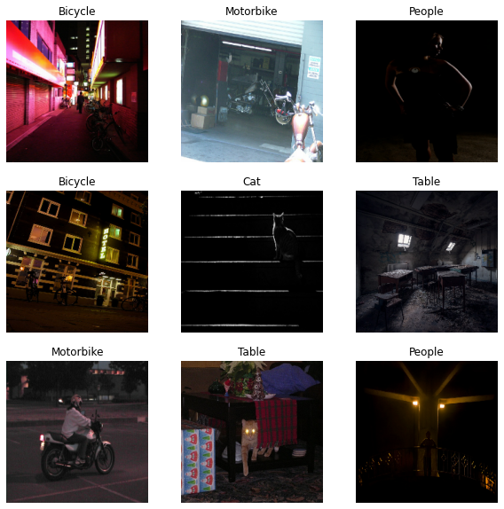

```python
# visualise the dataset
plt.figure(figsize=(10, 10))
for images, labels in train_ds.take(1):
    for i in range(9):
        ax = plt.subplot(3, 3, i + 1)
        plt.imshow(images[i].numpy().astype("uint8"))
        plt.title(class_names[labels[i]])
        plt.axis("off")
```

### Set Up Callbacks

```python
# for tensorboard callbacks
log_dir =  "/kaggle/working/logs/fit/" + datetime.datetime.now().strftime("%Y%m%d-%H%M%S")
tensorboard_callback = tf.keras.callbacks.TensorBoard(log_dir=log_dir, histogram_freq=1)

# Creates a file writer for the log directory.
file_writer = tf.summary.create_file_writer(log_dir)
```

```python
# %tensorboard --logdir $log_dir
```

```python
def plot_confusion_matrix(cm, class_names):
    """
    Returns a matplotlib figure containing the plotted confusion matrix.

    Args:
    cm (array, shape = [n, n]): a confusion matrix of integer classes
    class_names (array, shape = [n]): String names of the integer classes
    """
    figure = plt.figure(figsize=(8, 8))
    plt.imshow(cm, interpolation='nearest', cmap=plt.cm.Blues)
    plt.title("Confusion matrix")
    plt.colorbar()
    tick_marks = np.arange(len(class_names))
    plt.xticks(tick_marks, class_names, rotation=45)
    plt.yticks(tick_marks, class_names)

    # Compute the labels from the normalized confusion matrix.
    labels = np.around(cm.astype('float') / cm.sum(axis=1)[:, np.newaxis], decimals=2)

    # Use white text if squares are dark; otherwise black.
    threshold = cm.max() / 2.
    for i, j in itertools.product(range(cm.shape[0]), range(cm.shape[1])):
        color = "white" if cm[i, j] > threshold else "black"
        plt.text(j, i, labels[i, j], horizontalalignment="center", color=color)

        plt.tight_layout()
        plt.ylabel('True label')
        plt.xlabel('Predicted label')
    return figure

def log_confusion_matrix(epoch, logs):
    # Use the model to predict the values from the validation dataset.
    test_pred_raw = model.predict(test_images)
    test_pred = np.argmax(test_pred_raw, axis=1)

    # Calculate the confusion matrix.
    cm = sklearn.metrics.confusion_matrix(test_labels, test_pred)
    # Log the confusion matrix as an image summary.
    figure = plot_confusion_matrix(cm, class_names=class_names)
    cm_image = plot_to_image(figure)

    # Log the confusion matrix as an image summary.
    with file_writer.as_default():
        tf.summary.image("Confusion Matrix", cm_image, step=epoch)


# Define the per-epoch callback.
cm_callback = tf.keras.callbacks.LambdaCallback(on_epoch_end=log_confusion_matrix)
```

```python
train_images = []
train_labels = []
count = 1
for img,label in train_ds.as_numpy_iterator():
    train_images.extend(img)
    train_labels.extend(label)

    count += len(label)
    if count > 25:
        break

train_images = np.array(train_images)
train_labels = np.array(train_labels)


train_images.shape,train_labels.shape
```

```
((32, 224, 224, 3), (32,))
```

```python
test_images = []
test_labels = []

for img,label in val_ds.as_numpy_iterator():

    test_images.extend(img)
    test_labels.extend(label)
test_images = np.array(test_images)
test_labels = np.array(test_labels)
```

```python
def plot_to_image(figure):
    """Converts the matplotlib plot specified by 'figure' to a PNG image and
    returns it. The supplied figure is closed and inaccessible after this call."""
    # Save the plot to a PNG in memory.
    buf = io.BytesIO()
    plt.savefig(buf, format='png')
    # Closing the figure prevents it from being displayed directly inside
    # the notebook.
    plt.close(figure)
    buf.seek(0)
    # Convert PNG buffer to TF image
    image = tf.image.decode_png(buf.getvalue(), channels=4)
    # Add the batch dimension
    image = tf.expand_dims(image, 0)
    return image

def image_grid():
    """Return a 5x5 grid of the Data images as a matplotlib figure."""
    # Create a figure to contain the plot.
    figure = plt.figure(figsize=(10,10))
    for i in range(25):
        # Start next subplot.
        plt.subplot(5, 5, i + 1, title=str(class_names[train_labels[i]]))
        plt.xticks([])
        plt.yticks([])
        plt.grid(False)
        plt.imshow(train_images[i])

    return figure

# Prepare the plot
figure = image_grid()
# Convert to image and log
with file_writer.as_default():
    tf.summary.image("Training data", plot_to_image(figure), step=0)

# %tensorboard --logdir logs/plots
```

```python
early_stopping_callback = tf.keras.callbacks.EarlyStopping(monitor='val_loss', patience=5)
```

```python
model_checkpoint_callback = tf.keras.callbacks.ModelCheckpoint(
    filepath=checkpoint_filepath,
    save_weights_only=False,
    monitor='val_accuracy',
    mode='max',
    save_best_only=True)
```

```python
# and decreases it exponentially after that.
def scheduler(epoch, lr):
    if epoch < 10:
        return lr
    else:
        return lr * tf.math.exp(-0.1)


learning_rateScheduler_callback = tf.keras.callbacks.LearningRateScheduler(scheduler)
```

## Model Configuration

```python
data_augmentation = tf.keras.Sequential([
  tf.keras.layers.experimental.preprocessing.RandomFlip('horizontal'),
  tf.keras.layers.experimental.preprocessing.RandomRotation(0.2),
])
```

```python
IMG_SHAPE = IMG_SIZE + (3,)

if BASE_MODEL == BASE_MODELS.mobilenetv2:
    print("Model Choosen: mobilenetv2")
    preprocess_input = tf.keras.applications.mobilenet_v2.preprocess_input
    base_model = tf.keras.applications.MobileNetV2(input_shape=IMG_SHAPE,
                                                   include_top=False,
                                                   weights='imagenet')

elif BASE_MODEL == BASE_MODELS.resnet50:
    print("Model Choosen: resnet50")
    preprocess_input = tf.keras.applications.resnet50.preprocess_input
    base_model = tf.keras.applications.ResNet50(input_shape=IMG_SHAPE,
                                                   include_top=False,
                                                weights='imagenet')
elif BASE_MODEL == BASE_MODELS.resnet101:
    print("Model Choosen: resnet50")
    preprocess_input = tf.keras.applications.resnet50.preprocess_input
    base_model = tf.keras.applications.ResNet50(input_shape=IMG_SHAPE,
                                                   include_top=False,
                                                weights='imagenet')

else:
    print("Falling Back to vgg16")
    preprocess_input = tf.keras.applications.vgg16.preprocess_input
    base_model = tf.keras.applications.VGG16(input_shape=IMG_SHAPE,
                                                   include_top=False,
                                                   weights='imagenet')

image_batch, label_batch = next(iter(train_ds))
feature_batch = base_model(image_batch)
print(feature_batch.shape)
```

```
Model Choosen: mobilenetv2
Downloading data from https://storage.googleapis.com/tensorflow/keras-applications/mobilenet_v2/mobilenet_v2_weights_tf_dim_ordering_tf_kernels_1.0_224_no_top.h5
(16, 7, 7, 1280)
```

```python
base_model.trainable = False
base_model.summary()
```

```
Model: "mobilenetv2_1.00_224"
__________________________________________________________________________________________________
Layer (type)                    Output Shape         Param #     Connected to
==================================================================================================
input_1 (InputLayer)            [(None, 224, 224, 3) 0
__________________________________________________________________________________________________
Conv1 (Conv2D)                  (None, 112, 112, 32) 864         input_1[0][0]
__________________________________________________________________________________________________
bn_Conv1 (BatchNormalization)   (None, 112, 112, 32) 128         Conv1[0][0]
__________________________________________________________________________________________________
Conv1_relu (ReLU)               (None, 112, 112, 32) 0           bn_Conv1[0][0]
__________________________________________________________________________________________________
expanded_conv_depthwise (Depthw (None, 112, 112, 32) 288         Conv1_relu[0][0]
__________________________________________________________________________________________________
expanded_conv_depthwise_BN (Bat (None, 112, 112, 32) 128         expanded_conv_depthwise[0][0]
__________________________________________________________________________________________________
expanded_conv_depthwise_relu (R (None, 112, 112, 32) 0           expanded_conv_depthwise_BN[0][0]
__________________________________________________________________________________________________
expanded_conv_project (Conv2D)  (None, 112, 112, 16) 512         expanded_conv_depthwise_relu[0][0
__________________________________________________________________________________________________
expanded_conv_project_BN (Batch (None, 112, 112, 16) 64          expanded_conv_project[0][0]
__________________________________________________________________________________________________
block_1_expand (Conv2D)         (None, 112, 112, 96) 1536        expanded_conv_project_BN[0][0]
__________________________________________________________________________________________________
block_1_expand_BN (BatchNormali (None, 112, 112, 96) 384         block_1_expand[0][0]
__________________________________________________________________________________________________
block_1_expand_relu (ReLU)      (None, 112, 112, 96) 0           block_1_expand_BN[0][0]
__________________________________________________________________________________________________
block_1_pad (ZeroPadding2D)     (None, 113, 113, 96) 0           block_1_expand_relu[0][0]
__________________________________________________________________________________________________
block_1_depthwise (DepthwiseCon (None, 56, 56, 96)   864         block_1_pad[0][0]
__________________________________________________________________________________________________
block_1_depthwise_BN (BatchNorm (None, 56, 56, 96)   384         block_1_depthwise[0][0]
__________________________________________________________________________________________________
block_1_depthwise_relu (ReLU)   (None, 56, 56, 96)   0           block_1_depthwise_BN[0][0]
__________________________________________________________________________________________________
block_1_project (Conv2D)        (None, 56, 56, 24)   2304        block_1_depthwise_relu[0][0]
__________________________________________________________________________________________________
block_1_project_BN (BatchNormal (None, 56, 56, 24)   96          block_1_project[0][0]
__________________________________________________________________________________________________
```

[output cut: 271 more lines]

```
__________________________________________________________________________________________________
block_16_project (Conv2D)       (None, 7, 7, 320)    307200      block_16_depthwise_relu[0][0]
__________________________________________________________________________________________________
block_16_project_BN (BatchNorma (None, 7, 7, 320)    1280        block_16_project[0][0]
__________________________________________________________________________________________________
Conv_1 (Conv2D)                 (None, 7, 7, 1280)   409600      block_16_project_BN[0][0]
__________________________________________________________________________________________________
Conv_1_bn (BatchNormalization)  (None, 7, 7, 1280)   5120        Conv_1[0][0]
__________________________________________________________________________________________________
out_relu (ReLU)                 (None, 7, 7, 1280)   0           Conv_1_bn[0][0]
==================================================================================================
Total params: 2,257,984
Trainable params: 0
Non-trainable params: 2,257,984
__________________________________________________________________________________________________
```

```python
global_average_layer = tf.keras.layers.GlobalAveragePooling2D()
feature_batch_average = global_average_layer(feature_batch)
print(feature_batch_average.shape)
```

```
(16, 1280)
```

```python
prediction_layer = tf.keras.layers.Dense(num_classes)
prediction_batch = prediction_layer(feature_batch_average)
print(prediction_batch.shape)
```

```
(16, 6)
```

```python
inputs = tf.keras.Input(shape=(img_width, img_height, 3))
x = data_augmentation(inputs)
x = preprocess_input(x)
x = base_model(x, training=False)
x = global_average_layer(x)
x = tf.keras.layers.Dropout(0.2)(x)
outputs = prediction_layer(x)
model = tf.keras.Model(inputs, outputs)
```

```python
model.summary()
```

```
Model: "model"
_________________________________________________________________
Layer (type)                 Output Shape              Param #
=================================================================
input_2 (InputLayer)         [(None, 224, 224, 3)]     0
_________________________________________________________________
sequential (Sequential)      (None, 224, 224, 3)       0
_________________________________________________________________
tf.math.truediv (TFOpLambda) (None, 224, 224, 3)       0
_________________________________________________________________
tf.math.subtract (TFOpLambda (None, 224, 224, 3)       0
_________________________________________________________________
mobilenetv2_1.00_224 (Functi (None, 7, 7, 1280)        2257984
_________________________________________________________________
global_average_pooling2d (Gl (None, 1280)              0
_________________________________________________________________
dropout (Dropout)            (None, 1280)              0
_________________________________________________________________
dense (Dense)                (None, 6)                 7686
=================================================================
Total params: 2,265,670
Trainable params: 7,686
Non-trainable params: 2,257,984
_________________________________________________________________
```

```python
base_learning_rate = 0.0001
model.compile(optimizer=tf.keras.optimizers.Adam(lr=base_learning_rate),
              loss= tf.keras.losses.SparseCategoricalCrossentropy(from_logits=True),
              metrics=['accuracy',tf.keras.metrics.SparseTopKCategoricalAccuracy(k=2)])
```

## Training Approach:

1. Step 1 : Train the newly attached layer freezing base_model
2. Step 2: Retrain the same model with some layer infreezed from prev layer and to be started at the epoch where it left in step 1

## Step 1:

### Train the newly attached layer

```python
# combine all callbacks
callbacks = [
    tensorboard_callback,
    learning_rateScheduler_callback,
    model_checkpoint_callback,
    early_stopping_callback,cm_callback
]
```

```python
epochs=50
history = model.fit(
  train_ds,
  validation_data=val_ds,
  epochs=epochs,
  callbacks=callbacks)
```

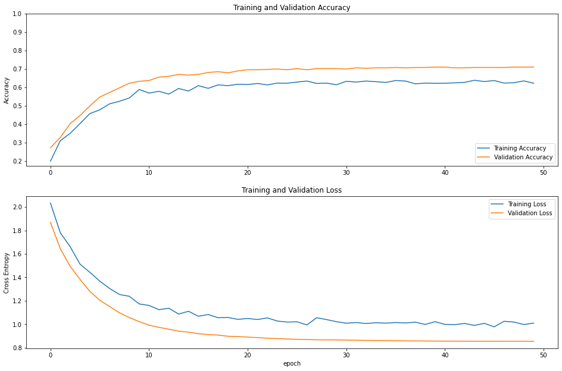

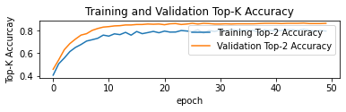

```python
acc = history.history['accuracy']
val_acc = history.history['val_accuracy']

loss = history.history['loss']
val_loss = history.history['val_loss']


train_topk_acc = history.history['sparse_top_k_categorical_accuracy']
val_topk_acc = history.history['val_sparse_top_k_categorical_accuracy']

plt.figure(figsize=(16, 16))
plt.subplot(3, 1, 1)
plt.plot(acc, label='Training Accuracy')
plt.plot(val_acc, label='Validation Accuracy')
plt.legend(loc='lower right')
plt.ylabel('Accuracy')
plt.ylim([min(plt.ylim()),1])
plt.title('Training and Validation Accuracy')

plt.subplot(3, 1, 2)
plt.plot(loss, label='Training Loss')
plt.plot(val_loss, label='Validation Loss')
plt.legend(loc='upper right')
plt.ylabel('Cross Entropy')
# plt.ylim([0,1.0])
plt.title('Training and Validation Loss')
plt.xlabel('epoch')
plt.show()


plt.subplot(3, 1, 3)
plt.plot(train_topk_acc, label='Training Top-2 Accuracy')
plt.plot(val_topk_acc, label='Validation Top-2 Accuracy')
plt.legend(loc='upper right')
plt.ylabel('Top-K Accurcay')
# plt.ylim([0,1.0])
plt.title('Training and Validation Top-K Accuracy')
plt.xlabel('epoch')
plt.show()
```

```python
# load the best model and evaluate
# model.load_weights(checkpoint_filepath)
best_model_before_fine_tune = tf.keras.models.load_model(checkpoint_filepath)


# best_model_before_fine_tune.evaluate_generator(val_ds)
# model.evaluate_generator(val_ds)
```

## Step 2:

### Train some fixed layer now

```python
base_model.trainable = True
```

```python
# Let's take a look to see how many layers are in the base model
print("Number of layers in the base model: ", len(base_model.layers))

# Fine-tune from this layer onwards
fine_tune_at = 100

# Freeze all the layers before the `fine_tune_at` layer
for layer in base_model.layers[:fine_tune_at]:
  layer.trainable =  False
```

```
Number of layers in the base model:  154
```

```python
model.compile(optimizer=tf.keras.optimizers.Adam(lr=base_learning_rate/10),
              loss=tf.keras.losses.SparseCategoricalCrossentropy(from_logits=True),
              metrics=['accuracy',tf.keras.metrics.SparseTopKCategoricalAccuracy(k=2)])
```

```python
model.summary()
```

```
Model: "model"
_________________________________________________________________
Layer (type)                 Output Shape              Param #
=================================================================
input_2 (InputLayer)         [(None, 224, 224, 3)]     0
_________________________________________________________________
sequential (Sequential)      (None, 224, 224, 3)       0
_________________________________________________________________
tf.math.truediv (TFOpLambda) (None, 224, 224, 3)       0
_________________________________________________________________
tf.math.subtract (TFOpLambda (None, 224, 224, 3)       0
_________________________________________________________________
mobilenetv2_1.00_224 (Functi (None, 7, 7, 1280)        2257984
_________________________________________________________________
global_average_pooling2d (Gl (None, 1280)              0
_________________________________________________________________
dropout (Dropout)            (None, 1280)              0
_________________________________________________________________
dense (Dense)                (None, 6)                 7686
=================================================================
Total params: 2,265,670
Trainable params: 1,869,126
Non-trainable params: 396,544
_________________________________________________________________
```

```python
fine_tune_epochs = 20
initial_epochs = epochs
total_epochs =  initial_epochs + fine_tune_epochs

history_fine = model.fit(train_ds,
                         epochs=total_epochs,
                         initial_epoch=history.epoch[-1],
                         validation_data=val_ds,
                        callbacks=callbacks)
```

```python
best_model_before_fine_tune = tf.keras.models.load_model(checkpoint_filepath)
```

```python
acc += history_fine.history['accuracy']
val_acc += history_fine.history['val_accuracy']

loss += history_fine.history['loss']
val_loss += history_fine.history['val_loss']


train_topk_acc += history.history['sparse_top_k_categorical_accuracy']
val_topk_acc += history.history['val_sparse_top_k_categorical_accuracy']
```

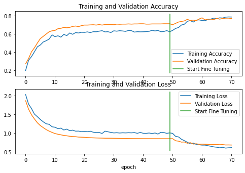

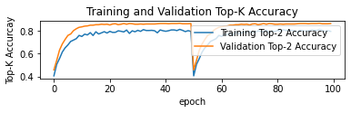

```python
plt.figure(figsize=(8, 8))
plt.subplot(3, 1, 1)
plt.plot(acc, label='Training Accuracy')
plt.plot(val_acc, label='Validation Accuracy')
# plt.ylim([0.8, 1])
plt.plot([initial_epochs-1,initial_epochs-1],
          plt.ylim(), label='Start Fine Tuning')
plt.legend(loc='lower right')
plt.title('Training and Validation Accuracy')

plt.subplot(3, 1, 2)
plt.plot(loss, label='Training Loss')
plt.plot(val_loss, label='Validation Loss')
# plt.ylim([0, 1.0])
plt.plot([initial_epochs-1,initial_epochs-1],
         plt.ylim(), label='Start Fine Tuning')
plt.legend(loc='upper right')
plt.title('Training and Validation Loss')
plt.xlabel('epoch')
plt.show()

plt.subplot(3, 1, 3)
plt.plot(train_topk_acc, label='Training Top-2 Accuracy')
plt.plot(val_topk_acc, label='Validation Top-2 Accuracy')
plt.legend(loc='upper right')
plt.ylabel('Top-K Accurcay')
# plt.ylim([0,1.0])
plt.title('Training and Validation Top-K Accuracy')
plt.xlabel('epoch')
plt.show()
```

```python
loss, accuracy, topk_acc = best_model_before_fine_tune.evaluate(val_ds)
print('Val accuracy :', accuracy )
print('Top-2 accuracy :', topk_acc )
```

```
Val accuracy : 0.7749999761581421
Top-2 accuracy : 0.8979166746139526
```

```python
model.summary()
```

```
Model: "model"
_________________________________________________________________
Layer (type)                 Output Shape              Param #
=================================================================
input_2 (InputLayer)         [(None, 224, 224, 3)]     0
_________________________________________________________________
sequential (Sequential)      (None, 224, 224, 3)       0
_________________________________________________________________
tf.math.truediv (TFOpLambda) (None, 224, 224, 3)       0
_________________________________________________________________
tf.math.subtract (TFOpLambda (None, 224, 224, 3)       0
_________________________________________________________________
mobilenetv2_1.00_224 (Functi (None, 7, 7, 1280)        2257984
_________________________________________________________________
global_average_pooling2d (Gl (None, 1280)              0
_________________________________________________________________
dropout (Dropout)            (None, 1280)              0
_________________________________________________________________
dense (Dense)                (None, 6)                 7686
=================================================================
Total params: 2,265,670
Trainable params: 1,869,126
Non-trainable params: 396,544
_________________________________________________________________
```

## Visualise the Model Predictions

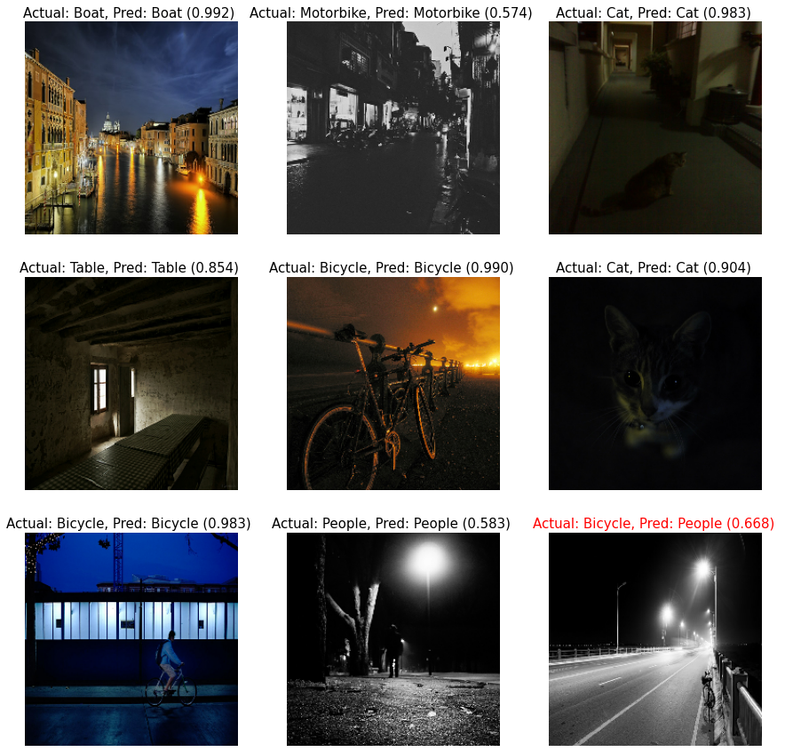

```python
# visualise the model results

fig = plt.figure(figsize=(15, 15))
for images, labels in train_ds.take(1):
    for i in range(9):
        ax = plt.subplot(3, 3, i + 1)
        plt.imshow(images[i].numpy().astype("uint8"))

        score = tf.nn.softmax(model.predict_on_batch(tf.expand_dims(images[i],axis=0))[0])

        pred_label = class_names[np.argmax(score)]
        pred_score = max(score)
        color = "#000000" if class_names[labels[i]] ==  pred_label else "#ff0000"

        text =  "Actual: %s, Pred: %s (%0.3f) "%(class_names[labels[i]],pred_label,pred_score)

        ax.set_title(text, fontsize=15, color= color);

        #plt.title(text)
        plt.axis("off")
#         break
```

```python
# !zip -qr ./savedmodel.zip ./checkpoint/
# !zip -qr ./logs.zip ./logs/
```

```python
!ls .
```

```
__notebook__.ipynb  checkpoint	logs  logs.zip	savedmodel.zip
```

### Submisison

1. logs: Tensorboard logs for visualisation. (Confusion Matrix, Train/Val/Loss,Sample Data, etc)
2. saved-model: benchmark deployable model (Mobilenet-V2)

```python
# load the best model for prediction
best_model_before_fine_tune = tf.keras.models.load_model("./savedmodel/")

test_img_path = '../Dataset'
test_csv_path = '../AI_Basic_Test/test_set.csv'

img_height = 224
img_width= 224

# finetuning
# Create the base model from the pre-trained model MobileNet V2

IMG_SIZE = (img_width, img_height)
```

```python
# read all the test images name from text.csv
test_ds = pd.read_csv(test_csv_path)
test_ds.head()
```

|  | Image_Path | Class |
| --- | --- | --- |
| 0 | Testing/2015_00417.jpg | NaN |
| 1 | Testing/2015_07261.jpg | NaN |
| 2 | Testing/2015_01083.jpg | NaN |
| 3 | Testing/2015_06722.jpg | NaN |
| 4 | Testing/2015_01124.jpg | NaN |

```python
test_ds['Class'] = test_ds['Class'].astype('str')
```

```python
# Cross check the dtype
test_ds.info()
```

```
<class 'pandas.core.frame.DataFrame'>
RangeIndex: 480 entries, 0 to 479
Data columns (total 2 columns):
 #   Column      Non-Null Count  Dtype
---  ------      --------------  -----
 0   Image_Path  480 non-null    object
 1   Class       480 non-null    object
dtypes: object(2)
memory usage: 7.6+ KB
```

```python
# predict one by one

for i in range(len(test_ds)):
    pred_label = 'NaN'
    try:
        img_path = test_ds.iloc[i]['Image_Path']
        img = Image.open(os.path.join(test_img_path,img_path)).convert('RGB').resize(IMG_SIZE)
        img  = np.array(img)
    #     img.show()

        score = tf.nn.softmax(best_model_before_fine_tune.predict_on_batch(tf.expand_dims(img,axis=0))[0])
        pred_label = class_names[np.argmax(score)]
#         print(pred_label)
    except ValueError as err:
        print(err)
        print(img_path)
        break
    finally:
        test_ds.at[i,'Class'] = pred_label
```

```python
# Check if Labels are in proper format
test_ds.head()
```

|  | Image_Path | Class |
| --- | --- | --- |
| 0 | Testing/2015_00417.jpg | Motorbike |
| 1 | Testing/2015_07261.jpg | Table |
| 2 | Testing/2015_01083.jpg | Boat |
| 3 | Testing/2015_06722.jpg | People |
| 4 | Testing/2015_01124.jpg | Boat |

```python
# save the dataframe
save_submission_path = "../test_dataset.csv"
test_ds.to_csv(save_submission_path,index=False)
```

## What Next?

1. Within given timeframe, I am able to achieve 89.79 top-2 Accuracy.
2. What could be done for better model

   2.1 More Dataset (from same distribution)

   2.2 Better Loss Function

   2.3 Dataset Analysis: Making a Chart of cases where model is failing, ex: Bike and People in one Image, external Noise, etc. and prepare strategy to tackle it.

   2.4 Hyper-parameter Optimisations: More No. of experiments

Author: Saurav Solanki

Email-id: sausol.solanki@gmail.com